# Statistical inference with the GSS data

Wayne Yang (waynejeyang@gmail.com)

## Setup

Loading required packages and Data

### Load packages

```r
library(ggplot2)
library(dplyr)
library(statsr)
```

### Load data

```r
load("~/Desktop/GSS.Rdata")
```

## Part 1: Data

The General Social Survey (GSS) attempts to study the growing complexity of the United States. Started in 1972, the GSS is a personal interview survey of demographic, behavioral, and attitudinal questions, plus other topics of special interest by the National Opinion Research Center.

The observations in the GSS data target the population of adults (18+ years) living in household within the United States. The personal interviews are observations taken using random sampling to be able to generalize the sample to the larger US population. The implications of this data collection method on the scope of inference is that we can only find an association/generalization and not causality. This is because the data collection are merely observations and not from an experimental set up with random assignment.

Potential bias includes:

- As data was collected through voluntary in-person interviews, underreporting of unwilling respondents could occur.
- The respondents may alter their answers to the survey to conceal undesired traits and behaviors

## Part 2: Research question

Is the respondent’s highest education degree linked with the possession of a gun at home?

Gun violence is an ongoing issue that the United States face with many daily crimes associated with the usage of guns. Violence caused by guns is undeniably due to the user who is pressing the gun trigger, however – we must agree that if the user didn’t have possession of a gun, the gun causing violence wouldn’t have occurred and casualties could’ve been prevented. It would be interesting to statistically visualize and calculate whether the education level of an individual influences whether the same individual possesses a gun at their home.

To attempt to answer this question, this data project was completed using the following variables:

- DEGREE – Respondents Highest Degree
- OWNGUN – Does the respondent have a gun at home
- YEAR – Year the survey response was obtained

## Part 3: Exploratory data analysis

The summary function was run to view a numerical summary of the variables; year, degree and owngun to grasp a better understanding whilst also obtaining the different levels within the variables to construct a well formatted plot accordingly.

```r
summary(gss$year)
```

```
##    Min. 1st Qu.  Median    Mean 3rd Qu.    Max.
##    1972    1983    1993    1992    2002    2012
```

```r
summary(gss$degree)
```

```
## Lt High School    High School Junior College       Bachelor       Graduate
##          11822          29287           3070           8002           3870
##           NA's
##           1010
```

```r
summary(gss$owngun)
```

```
##     Yes      No Refused    NA's
##   14000   20144     315   22602
```

The owngun variable contained the unwanted level of “Refused”. Hence, to remove it so that only the levels of “Yes” and “No” remained, the following code was applied.

```r
gss <- subset(gss, owngun !="Refused")
gss$owngun <- droplevels(gss)$owngun
table(gss$owngun)
```

```
##
##   Yes    No
## 14000 20144
```

The selection of the variables that will be required to answer my research question – degree & owngun whilst also omitting all NA from the data. Then, the table function was run to view a two-way table of rsq1.

```r
rsq1 <- select(gss,degree,owngun) %>% na.omit()
table(rsq1)
```

```
##                 owngun
## degree            Yes   No
##   Lt High School 2876 4356
##   High School    7725 9771
##   Junior College  749 1031
##   Bachelor       1634 3030
##   Graduate        753 1584
```

The bar geom within the ggplot2 library is used here to view a visual summary of the data due to the categorical data. The highest level of education is located on the x axis and the possession of a gun is located on the Y axis as a fill to the bars.

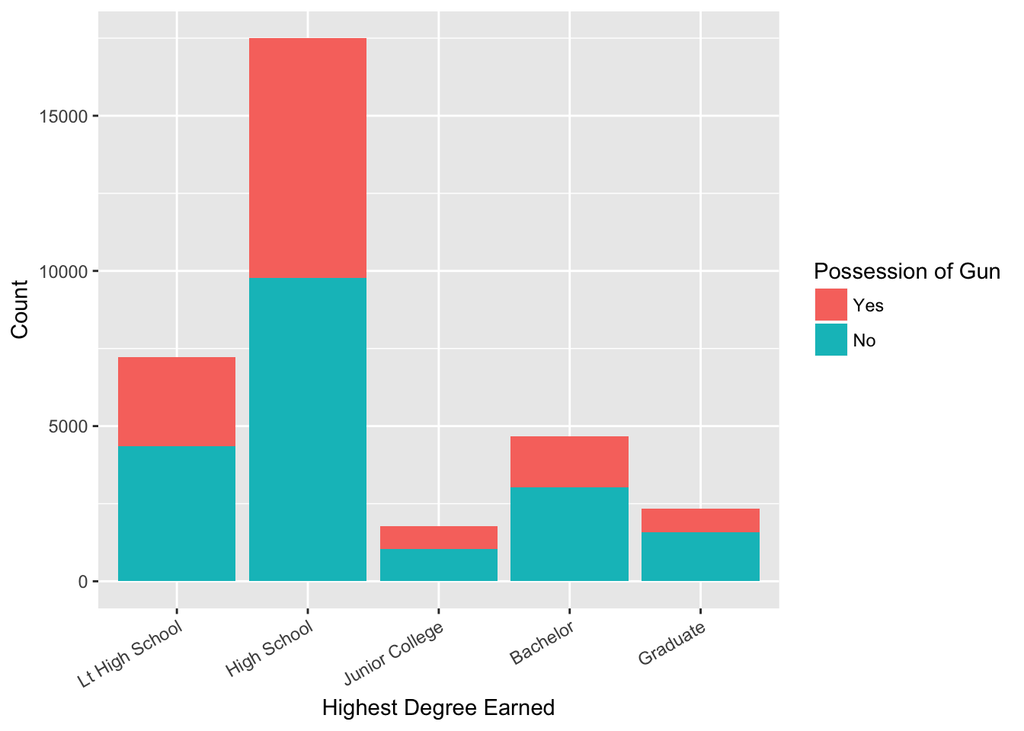

```r
plot1 <- ggplot(rsq1, aes(x = degree, fill = owngun)) +
  geom_bar() +
  xlab("Highest Degree Earned") +
  ylab("Count") +
  scale_fill_discrete(name="Possession of Gun") +
  theme(axis.text.x=element_text(angle=30, hjust=1))
plot1
```

Using position = ”fill”, the ratio of “Yes” and “No” was used to fill the bars to approximate all counts to 1. The decision to do this was to be able to visually examine the ratio of gun possession within each education level for comparison amongst the groups.

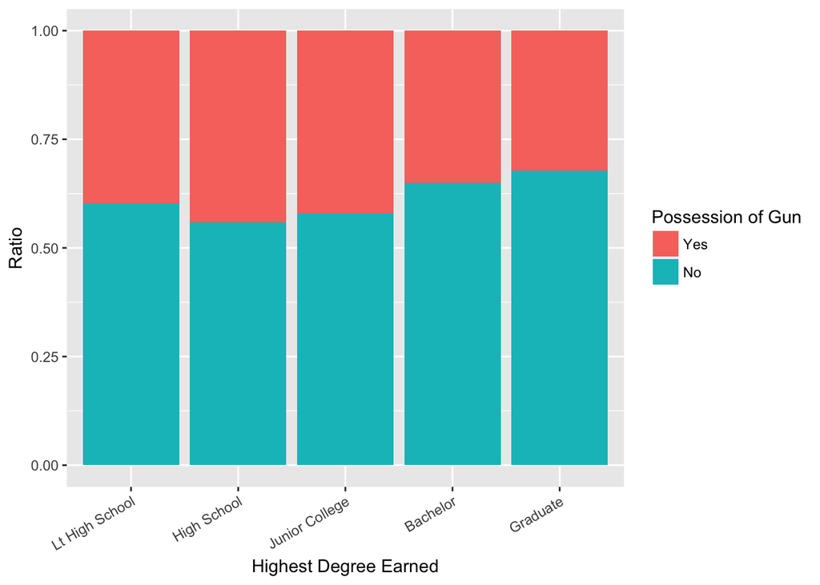

```r
plot1 <- ggplot(rsq1, aes(x = degree, fill = owngun)) +
  geom_bar(position = "fill") +
  xlab("Highest Degree Earned") +
  ylab("Ratio") +
  scale_fill_discrete(name="Possession of Gun") +
  theme(axis.text.x=element_text(angle=30, hjust=1))
plot1
```

```r
#Note - Lt High School = Limited High School
```

## Part 4: Inference

Hypotheses

The null hypothesis is that the respondent’s highest education degree level is independent with whether they possess a gun.

The alternative hypothesis is that respondent’s highest education degree level is linked and varies with whether they possess a gun.

Conditions

We can assume that there is independence between observations due to the methodology behind the gathering of the data by GSS – random sampling. Also, the size of the sample (33509) is less than 10% of the population and each case only contributes to one cell in the numerical table.

```r
str(rsq1)
```

```
## 'data.frame':    33509 obs. of  2 variables:
##  $ degree: Factor w/ 5 levels "Lt High School",..: 1 1 1 2 1 2 1 4 4 1 ...
##  $ owngun: Factor w/ 2 levels "Yes","No": 1 1 1 1 1 2 2 2 2 1 ...
##  - attr(*, "na.action")=Class 'omit'  Named int [1:635] 9 25 29 65 102 160 174 185 199 210 ...
##   .. ..- attr(*, "names")= chr [1:635] "1622" "1638" "1642" "1678" ...
```

Methods

My dataset (rsq1) consists of two categorical variables: degree & owngun. Hence the chi-square independence test will be used to evaluate the relationship between these two categorical variables. Note that the degree variables has >2 levels, therefore this test can be applied.

The following code describes the method of finding X-squared as well as the degrees of freedom.

```r
cst_rsq1 <- chisq.test(rsq1$degree,rsq1$owngun)
cst_rsq1
```

```
##
##  Pearson's Chi-squared test
##
## data:  rsq1$degree and rsq1$owngun
## X-squared = 220.39, df = 4, p-value < 2.2e-16
```

From the results above – a relatively high X-squared value of 220.39 and a low p-value of < 2.2e-16

We can compare the expected and the observed values using the following functions. The expected values are calculated assuming that the null hypothesis is true.

```r
cst_rsq1$expected
```

```
##                 rsq1$owngun
## rsq1$degree            Yes        No
##   Lt High School 2964.7553  4267.245
##   High School    7172.4776 10323.522
##   Junior College  729.7102  1050.290
##   Bachelor       1912.0048  2751.995
##   Graduate        958.0521  1378.948
```

```r
cst_rsq1$observed
```

```
##                 rsq1$owngun
## rsq1$degree       Yes   No
##   Lt High School 2876 4356
##   High School    7725 9771
##   Junior College  749 1031
##   Bachelor       1634 3030
##   Graduate        753 1584
```

Interpretations & Conclusions

As the calculated P-value is less than the significance level of 0.05, we can conclude that there is sufficient evidence to reject the null hypothesis. This means that there is a significant difference between the observed and expected value, thus chance isn’t the underlying reason behind these differences.

Note that this project isn’t a two proportion test due to the multiple levels within the categorical variable (degree). Thus a confidence interval wasn’t included within this analysis.